# Practical Machine Learning Course Project

Jack Shih

1/20/2019

## Executive Summary

#### Background

Using devices such as Jawbone Up, Nike FuelBand, and Fitbit it is now possible to collect a large amount of data about personal activity relatively inexpensively. These type of devices are part of the quantified self movement – a group of enthusiasts who take measurements about themselves regularly to improve their health, to find patterns in their behavior, or because they are tech geeks. One thing that people regularly do is quantify how much of a particular activity they do, but they rarely quantify how well they do it. In this project, your goal will be to use data from accelerometers on the belt, forearm, arm, and dumbell of 6 participants. They were asked to perform barbell lifts correctly and incorrectly in 5 different ways. More information is available from the website here: http://web.archive.org/web/20161224072740/http:/groupware.les.inf.puc-rio.br/har (see the section on the Weight Lifting Exercise Dataset).

#### Data

The training data for this project are available here:

https://d396qusza40orc.cloudfront.net/predmachlearn/pml-training.csv

The test data are available here:

https://d396qusza40orc.cloudfront.net/predmachlearn/pml-testing.csv

## Setup

Load packages, download data file, and data cleansing

```r
library(ggplot2)
library(caret)
library(rattle)
training <- read.csv("https://d396qusza40orc.cloudfront.net/predmachlearn/pml-training.csv")
test <- read.csv("https://d396qusza40orc.cloudfront.net/predmachlearn/pml-testing.csv")
set.seed(28);

count_NA <- sapply(test, function(y) sum((is.na(y))))
NA_values <- count_NA[count_NA == 20]
var_remove <- names(NA_values)

training <- training[,!(names(training) %in% var_remove)]
test <- test[,!(names(test) %in% var_remove)]

var_remove2 <- c('user_name','raw_timestamp_part_1', 'raw_timestamp_part_2', 'cvtd_timestamp', 'new_window', 'num_window', 'X')

training <- training[,!(names(training) %in% var_remove2)]
test <- test[,!(names(test) %in% var_remove2)]

my_partition <- createDataPartition(training$classe, p=0.6, list=FALSE)
my_train <- training[my_partition,]
my_test <- training[-my_partition,]
```

## Model

#### Random Forest

```r
mod1 <- train(classe ~ ., method="rf", data=my_train, trControl=trainControl(method="cv", number=3))

mod1$finalModel
```

```
##
## Call:
##  randomForest(x = x, y = y, mtry = param$mtry)
##                Type of random forest: classification
##                      Number of trees: 500
## No. of variables tried at each split: 27
##
##         OOB estimate of  error rate: 0.62%
## Confusion matrix:
##      A    B    C    D    E class.error
## A 3341    6    0    0    1 0.002090800
## B   14 2258    7    0    0 0.009214568
## C    0   10 2037    7    0 0.008276534
## D    0    0   21 1908    1 0.011398964
## E    0    0    5    1 2159 0.002771363
```

#### Model Validation subset of train data

```r
my_predict <- predict(mod1, newdata=my_test)
confusionMatrix(my_test$classe, my_predict)
```

```
## Confusion Matrix and Statistics
##
##           Reference
## Prediction    A    B    C    D    E
##          A 2229    2    1    0    0
##          B   14 1499    5    0    0
##          C    0    8 1349   11    0
##          D    0    1   15 1266    4
##          E    0    2    4    1 1435
##
## Overall Statistics
##
##                Accuracy : 0.9913
##                  95% CI : (0.989, 0.9933)
##     No Information Rate : 0.2859
##     P-Value [Acc > NIR] : < 2.2e-16
##
##                   Kappa : 0.989
##  Mcnemar's Test P-Value : NA
##
## Statistics by Class:
##
##                      Class: A Class: B Class: C Class: D Class: E
## Sensitivity            0.9938   0.9914   0.9818   0.9906   0.9972
## Specificity            0.9995   0.9970   0.9971   0.9970   0.9989
## Pos Pred Value         0.9987   0.9875   0.9861   0.9844   0.9951
## Neg Pred Value         0.9975   0.9979   0.9961   0.9982   0.9994
## Prevalence             0.2859   0.1927   0.1751   0.1629   0.1834
## Detection Rate         0.2841   0.1911   0.1719   0.1614   0.1829
## Detection Prevalence   0.2845   0.1935   0.1744   0.1639   0.1838
## Balanced Accuracy      0.9966   0.9942   0.9894   0.9938   0.9981
```

#### Decision Tree

```r
mod2 <- train(classe ~ ., data=my_train, method="rpart")
print(mod2$finalModel)
```

```
## n= 11776
##
## node), split, n, loss, yval, (yprob)
##       * denotes terminal node
##
##  1) root 11776 8428 A (0.28 0.19 0.17 0.16 0.18)
##    2) roll_belt< 130.5 10798 7459 A (0.31 0.21 0.19 0.18 0.11)
##      4) pitch_forearm< -34.35 932    3 A (1 0.0032 0 0 0) *
##      5) pitch_forearm>=-34.35 9866 7456 A (0.24 0.23 0.21 0.2 0.12)
##       10) magnet_dumbbell_y< 432.5 8277 5928 A (0.28 0.18 0.24 0.19 0.11)
##         20) roll_forearm< 122.5 5150 3036 A (0.41 0.18 0.19 0.17 0.063) *
##         21) roll_forearm>=122.5 3127 2105 C (0.075 0.18 0.33 0.23 0.18) *
##       11) magnet_dumbbell_y>=432.5 1589  795 B (0.038 0.5 0.049 0.23 0.19) *
##    3) roll_belt>=130.5 978    9 E (0.0092 0 0 0 0.99) *
```

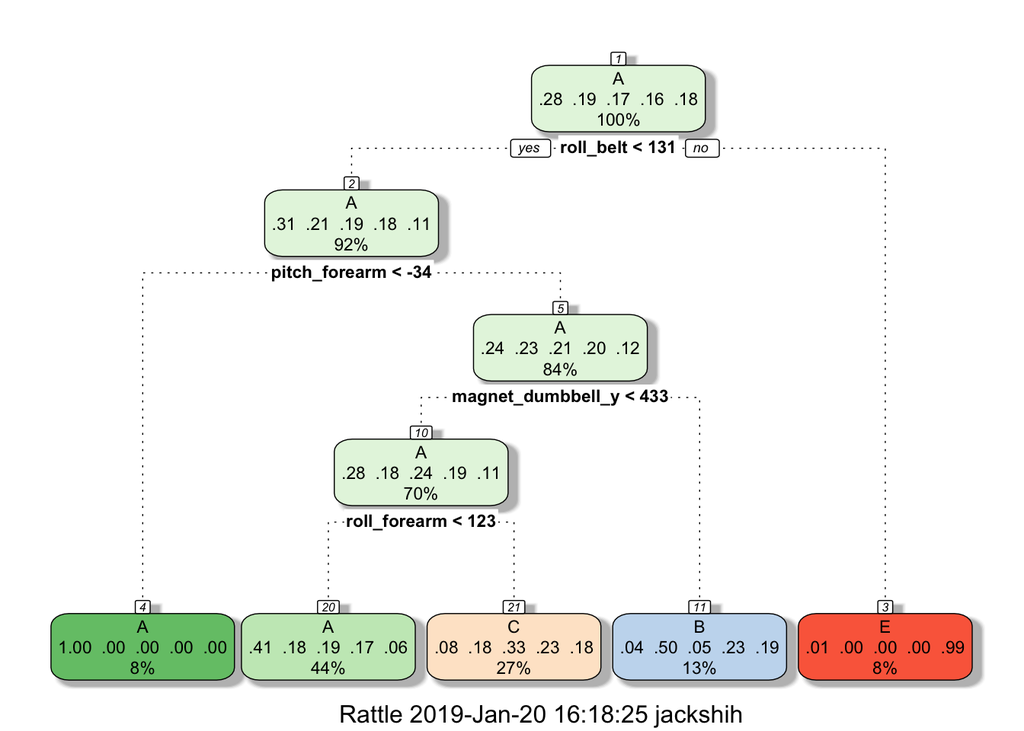

```r
fancyRpartPlot(mod2$finalModel)
```

```r
dt_predict <- predict(mod2, newdata=my_test)
confusionMatrix(dt_predict, my_test$classe)
```

```
## Confusion Matrix and Statistics
##
##           Reference
## Prediction    A    B    C    D    E
##          A 2009  625  627  565  192
##          B   46  526   37  238  207
##          C  172  367  704  483  381
##          D    0    0    0    0    0
##          E    5    0    0    0  662
##
## Overall Statistics
##
##                Accuracy : 0.4972
##                  95% CI : (0.4861, 0.5083)
##     No Information Rate : 0.2845
##     P-Value [Acc > NIR] : < 2.2e-16
##
##                   Kappa : 0.3435
##  Mcnemar's Test P-Value : NA
##
## Statistics by Class:
##
##                      Class: A Class: B Class: C Class: D Class: E
## Sensitivity            0.9001  0.34651  0.51462   0.0000  0.45908
## Specificity            0.6421  0.91656  0.78342   1.0000  0.99922
## Pos Pred Value         0.5000  0.49905  0.33412      NaN  0.99250
## Neg Pred Value         0.9417  0.85395  0.88430   0.8361  0.89135
## Prevalence             0.2845  0.19347  0.17436   0.1639  0.18379
## Detection Rate         0.2561  0.06704  0.08973   0.0000  0.08437
## Detection Prevalence   0.5121  0.13434  0.26854   0.0000  0.08501
## Balanced Accuracy      0.7711  0.63153  0.64902   0.5000  0.72915
```

#### Validation using test set

```r
my_test_predict <- predict(mod1, newdata=test)
write_prediction = function(x){
  n = length(x)
  for(i in 1:n){
    filename = paste0("problem_id_",i,".txt")
    write.table(x[i],file=filename,quote=FALSE,row.names=FALSE,col.names=FALSE)
  }
}

write_prediction(my_test_predict)
```